# Hard Work 11

## Instructions

1. Study Sections 11.4 (first) and then 11.3 – “Regression Trees and Robust Regression.”
2. Attempt and submit at least {44} Hard Work Points by Saturday at 11:59 PM.  
   Over {47} gets you {+1} Final Exam Point.

## Reading Points {19} Possible

### Section 11.4 {7}{ A=7 | E=4 }

### Section 11.3 {12}{ A=12 | E=9 }

## Theory Points {4} Possible

### Problem 11.2 {2}{ A=2 | E=2 }

When you run robust regression it weights outliers less then the data that is effecting the line the most. This way you don’t have to exclude outliers but they don’t play a huge weight into your regression model.

### Problem 11.4 {2}{ A=2 | E=2 }

You will have to many nodes when you have a small sample with to many predictors. This will cause small chunks of data to have their own mean but it won’t be worth anything because the sample size of the sample size will be very small.

## Application Points {25} Possible

[Data Files](http://www.stat.ufl.edu/~rrandles/sta4210/Rclassnotes/data/textdatasets/index.html)

### Problem CO2 {10}{ A=10 | E=10 }

Create a graphic similar to Figure 11.9 of the textbook for the CO2 data. Interpret your graphic.

```r
# Install the party library
# Run once: install.packages("party")
library(party)
library(MASS)
library(tidyverse)
library(mosaic)
library(car)
```

## Application 1

```r
# Set eval=TRUE to run this code.
ctree <- ctree(uptake ~ conc + Treatment + Type, data=CO2)
plot(ctree, type="simple")
unique(predict(ctree))
# Hint
```

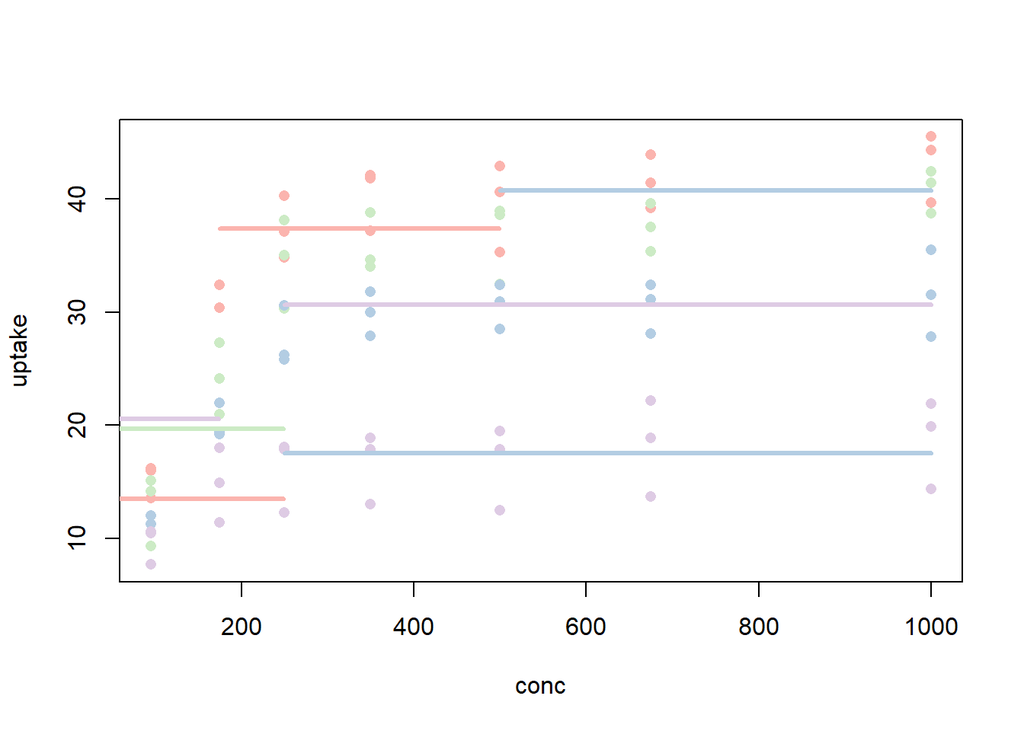

```r
palette(c("#FBB4AE", "#B3CDE3", "#CCEBC5", "#DECBE4"))
plot(uptake ~ conc, data=CO2, col=interaction(Type,Treatment), pch=16)
lines(c(0, 174), c(20.575,20.575), lwd=3, col="#DECBE4")
lines(c(175,499), c(37.383,37.383), lwd = 3, col = "#FBB4AE")
lines(c(500,1000), c(40.750,40.750), lwd = 3, col = "#B3CDE3")
lines(c(0,249), c(19.67778,19.67778), lwd = 3, col = "#CCEBC5")
lines(c(250,1000), c(30.65833,30.65833), lwd = 3, col = "#DECBE4")
lines(c(0,249), c(13.48889,13.48889), lwd = 3, col = "#FBB4AE")
lines(c(250,1000), c(17.55833,17.55833), lwd = 3, col = "#B3CDE3")
```

### Problem 11.11 {7}{ A=7 | E=7 }

## Application 2

```r
# Code to read in the data
# It has to be merged from the 1.20 and 8.15 data files.
p11.11 <- read.table("http://www.stat.ufl.edu/~rrandles/sta4210/Rclassnotes/data/textdatasets/KutnerData/Chapter%2011%20Data%20Sets/CH11PR11.txt", header=FALSE)

p1.20 <- read.table("http://www.stat.ufl.edu/~rrandles/sta4210/Rclassnotes/data/textdatasets/KutnerData/Chapter%20%201%20Data%20Sets/CH01PR20.txt", header=FALSE)

p11.11 <- rbind(p1.20, p11.11)

# Give it nice column names for conevience:
colnames(p11.11) <- c("Y","X1")
colnames(p1.20) <- c("Y", "X1")

# Show the data:
# p11.11
```

# A

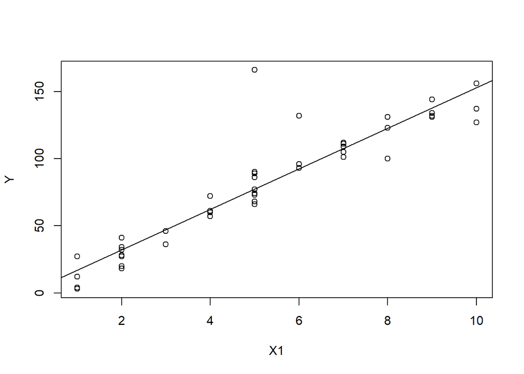

```r
plot(Y ~ X1, data = p11.11)
model <- lm(Y ~ X1, data = p11.11)
abline(model)
```

```r
summary(model)
```

```
##
## Call:
## lm(formula = Y ~ X1, data = p11.11)
##
## Residuals:
##     Min      1Q  Median      3Q     Max
## -25.980  -6.761  -2.323   3.903  88.567
##
## Coefficients:
##             Estimate Std. Error t value Pr(>|t|)
## (Intercept)   1.8860     5.3672   0.351    0.727
## X1           15.1094     0.9266  16.307   <2e-16 ***
## ---
## Signif. codes:  0 '***' 0.001 '**' 0.01 '*' 0.05 '.' 0.1 ' ' 1
##
## Residual standard error: 17.12 on 45 degrees of freedom
## Multiple R-squared:  0.8553, Adjusted R-squared:  0.852
## F-statistic: 265.9 on 1 and 45 DF,  p-value: < 2.2e-16
```

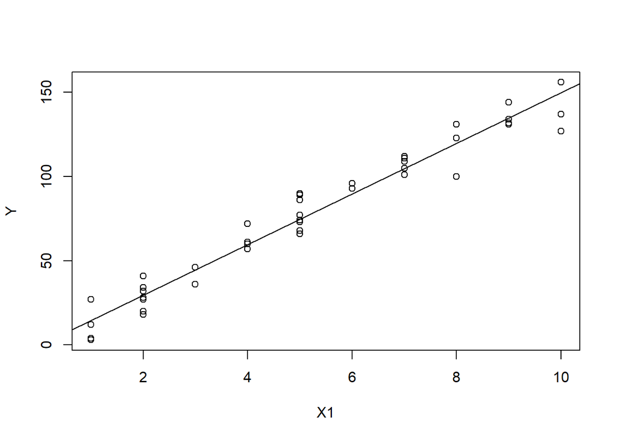

```r
plot(Y ~ X1, data = p1.20)
model <- lm(Y ~ X1, data = p1.20)
abline(model)
```

```r
summary(model)
```

```
##
## Call:
## lm(formula = Y ~ X1, data = p1.20)
##
## Residuals:
##      Min       1Q   Median       3Q      Max
## -22.7723  -3.7371   0.3334   6.3334  15.4039
##
## Coefficients:
##             Estimate Std. Error t value Pr(>|t|)
## (Intercept)  -0.5802     2.8039  -0.207    0.837
## X1           15.0352     0.4831  31.123   <2e-16 ***
## ---
## Signif. codes:  0 '***' 0.001 '**' 0.01 '*' 0.05 '.' 0.1 ' ' 1
##
## Residual standard error: 8.914 on 43 degrees of freedom
## Multiple R-squared:  0.9575, Adjusted R-squared:  0.9565
## F-statistic: 968.7 on 1 and 43 DF,  p-value: < 2.2e-16
```

Y = 1.8860 + 15.1094 * x Y = -0.5802 + 15.0352 * x

# B

```r
lm1 <- lm(Y ~ X1, data = p11.11)
MAD <- 1/0.6745 * median(abs(lm1$res - median(lm1$res)))
ui <- lm1$res/MAD

#Huber:
w <- ifelse(abs(ui) <= 1.345, 1, 1.345/abs(ui))

lm2 <- lm(Y ~ X1, data = p11.11, weights=w)
MAD <- 1/0.6745*median(abs(lm2$res - median(lm2$res)))
ui <- lm2$res/MAD

#Huber:
w2 <- ifelse(abs(ui) <= 1.345, 1, 1.345/abs(ui))

lm3 <- lm(Y ~ X1, data = p11.11, weights = w2)
MAD <- 1/0.6745*median(abs(lm3$res - median(lm3$res)))
ui <- lm3$res/MAD

w3 <- ifelse(abs(ui) <= 1.345, 1, 1.345/abs(ui))

lm4 <- lm(Y ~ X1, data = p11.11, weights = w3)
```

Smallest is case 47 at 0.1301640 Case 46 is 0.2921668

# C

Y = -0.9235 + 13.552 * x

# D

Smallest case 46 .12629, case 46 is .27858 Y = -1.5347 + 15.4247 * x Y = -1.6778 + 15.4436 * x

# E

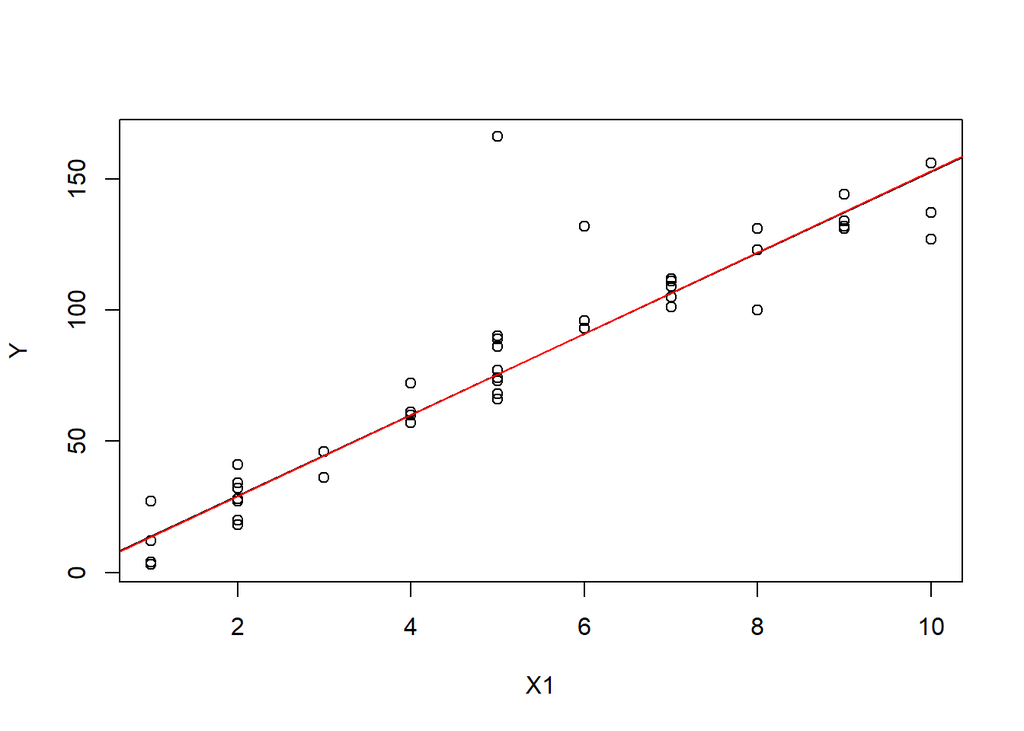

```r
lm5 <- rlm(Y ~ X1, data = p11.11)
plot(Y ~ X1, data = p11.11)
abline(lm4)
abline(lm5, col = "red")
```

### Problem 11.12 {8}{ A=8 | E=8 }

## Application 3

```r
# Code to read in the data
# It has to be merged from the 1.20 and 8.15 data files.
p11.12 <- read.table("http://www.stat.ufl.edu/~rrandles/sta4210/Rclassnotes/data/textdatasets/KutnerData/Chapter%2011%20Data%20Sets/CH11PR12.txt", header=FALSE)

# Give it nice column names for conevience:
colnames(p11.12) <- c("Y","X1")

# Show the data:
# p11.12
```

# A

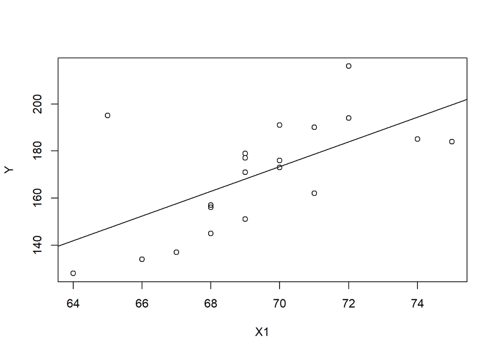

```r
plot(Y ~ X1, data = p11.12)
model <- lm(Y ~ X1, data = p11.12)
abline(model)
```

```r
summary(model)
```

```
##
## Call:
## lm(formula = Y ~ X1, data = p11.12)
##
## Residuals:
##     Min      1Q  Median      3Q     Max
## -20.716 -15.955  -3.213  10.228  47.780
##
## Coefficients:
##             Estimate Std. Error t value Pr(>|t|)
## (Intercept) -193.924    108.313  -1.790  0.09022 .
## X1             5.248      1.561   3.363  0.00346 **
## ---
## Signif. codes:  0 '***' 0.001 '**' 0.01 '*' 0.05 '.' 0.1 ' ' 1
##
## Residual standard error: 18.76 on 18 degrees of freedom
## Multiple R-squared:  0.3859, Adjusted R-squared:  0.3517
## F-statistic: 11.31 on 1 and 18 DF,  p-value: 0.003464
```

# B

```r
lm1 <- lm(Y ~ X1, data = p11.12)
MAD <- 1/0.6745 * median(abs(lm1$res - median(lm1$res)))
ui <- lm1$res/MAD

#Huber:
w <- ifelse(abs(ui) <= 1.345, 1, 1.345/abs(ui))

lm2 <- lm(Y ~ X1, data = p11.12, weights=w)
MAD <- 1/0.6745*median(abs(lm2$res - median(lm2$res)))
ui <- lm2$res/MAD

#Huber:
w2 <- ifelse(abs(ui) <= 1.345, 1, 1.345/abs(ui))

lm3 <- lm(Y ~ X1, data = p11.12, weights = w2)
MAD <- 1/0.6745*median(abs(lm3$res - median(lm3$res)))
ui <- lm3$res/MAD

w3 <- ifelse(abs(ui) <= 1.345, 1, 1.345/abs(ui))

lm4 <- lm(Y ~ X1, data = p11.12, weights = w3)
```

Smallest is 1

# C

Y = -236.259 + 5.838 * x

# D

Y = -241.577 + 5.914 * x Y = -242.606 + 5.928 * x